# Framing discussion

Author

Emily Nazario

Published

October 1, 2024

## In this doc

I’ve sketched out a rough outline of what the discussion could include and my initial thoughts on how we may interpret the figures/selected results. I would love feedback on the figures themselves as well as what information we may want to include when discussing the results themselves. To refresh, I’ve included the study objectives and hypotheses here.

### Hypotheses

**H1:** The AGI model will perform better than the dissolved oxygen and base model, and the dissolved oxygen model will perform better than the base model.

*Study objective:* Which model performs the best and presents the best predictions (i.e., best predictive performance scores, most ecologically realistic suitability maps)?

**H2:** The inclusion ofdissolved oxygen and the AGI at deeper depths will result in better performing/more ecologically realistic habitat suitability predictions relative to the respective models considering surface values alone.

*Study objective:* How does dissolved oxygen/AGI at different depths influence habitat suitability predictions relative to oxygen/AGI at the surface? How does the relative importance of each depth layer differ?

**H3:** At lower latitudes and near shore, the AGI will reach values close to 1.

*Study objective:* What spatial patterns can be observed with dissolved oxygen and the AGI?

**H4:** The base model will predict higher habitat suitability in areas or during seasons or periods with lower dissolved oxygen (e.g., upwelling periods or La Niña years) through the water column relative to the dissolved oxygen and AGI models.

Study *objective:* How do the habitat suitability maps differ between the models? How do these variations compare for different points in time with varying degrees of oxygenation?

## Discussion

- Will first review hypotheses and where we landed with each of them given the results
- **Overarching Result 1:** Spatial insights from including DO and AGI relative to the base model

  ```
  [1] "Base hsi > 0.50: 25.91%"
  ```

  ```
  [1] "DO hsi > 0.50: 26.82%"
  ```

  ```
  [1] "agi hsi > 0.50: 21.6%"
  ```

  ```
  [1] "combo hsi > 0.50: 27.25%"
  ```

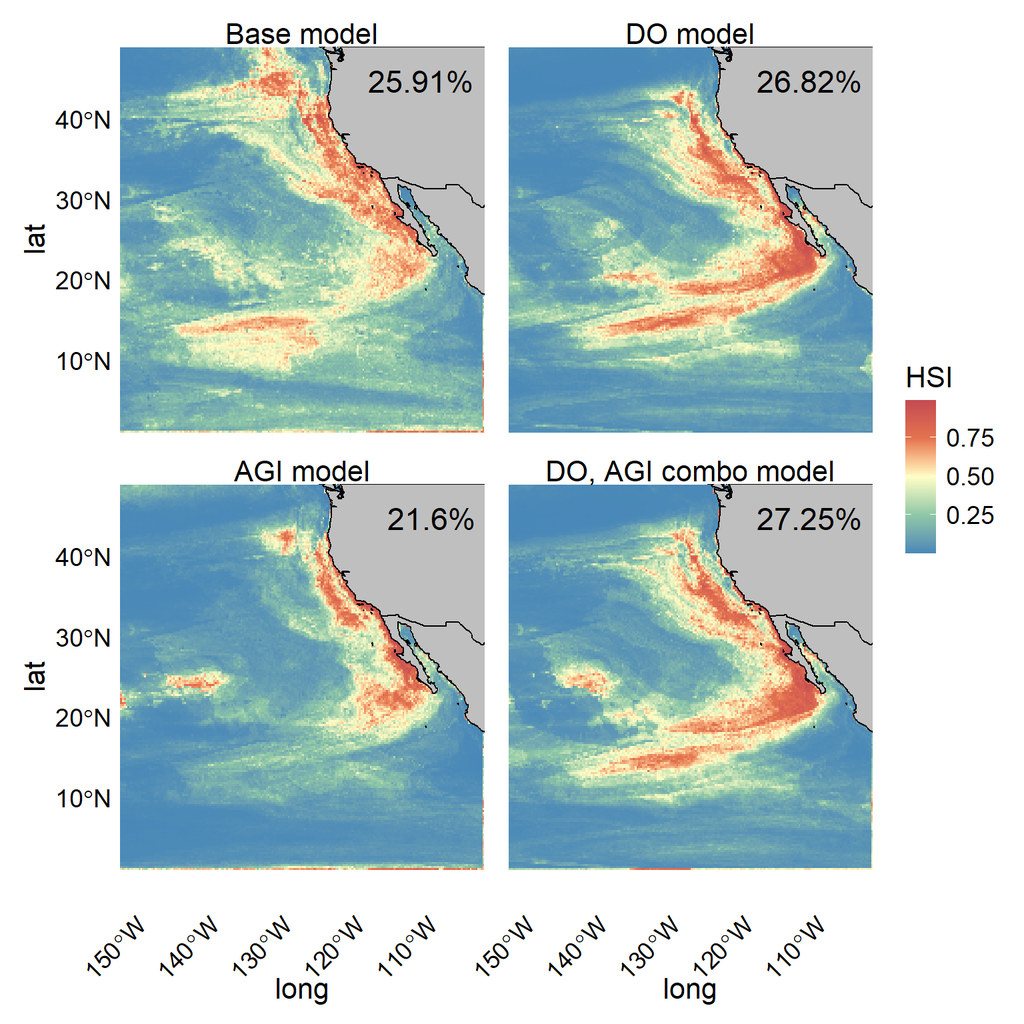

  - Base and DO model identify low DO area of Pacific North Equatorial Current (PNEC) as highly suitable habitat, while AGI only model doesn’t. Possibly showing a distinction of including metabolic demands relative to environmental features alone.
  - Implications for understanding immature mako habitat use.
    - All maps indicate high coastal habitat suitability, which is in agreement with previous work detailing immature/juvenile mako habitat use. All models outside of the AGI model, however, also indicate some offshore suitability and a wide latitudinal spread up through the CCS. Possibly suggesting more suitability available than previously described for immature individuals (Carreón-Zapiain et al. 2018);(Nasby-Lucas et al. 2019).
      - Could indicate that the AGI model provides distinct insight better capturing habitat use that models that don’t account for oxygen (base model) or that account for oxygen alone (DO model) rather than its interactive effects with temperature and the physiological implications.
    - Though, the SCBe still holds a high concentration of regions with high habitat suitability across all model types, agreeing with previous tagging efforts completed for immature mako sharks (Nosal et al. 2019);(Nasby-Lucas et al. 2019).
    - Could have concerning conservation implications as these coastal and low latitude regions in the CCS may be some of the most metabolically vulnerable under future climate scenarios (Deutsch et al. 2015).

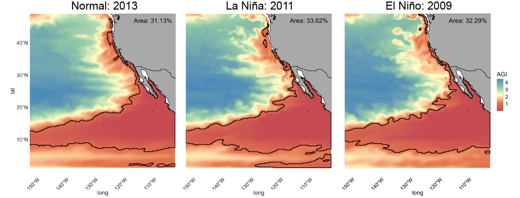

## References

Carreón-Zapiain, Marı́a Teresa, Susana Favela-Lara, Jaime Otilio González-Pérez, R Tavares, Antonio Leija-Tristán, Roberto Mercado-Hernández, and GA Compeán-Jiménez. 2018. “Size, Age, and Spatial–Temporal Distribution of Shortfin Mako in the Mexican Pacific Ocean.” *Marine and Coastal Fisheries* 10 (4): 402–10. https://doi.org/10.1002/mcf2.10029.

Deutsch, Curtis, Aaron Ferrel, Brad Seibel, Hans-Otto Pörtner, and Raymond B. Huey. 2015. “Climate Change Tightens a Metabolic Constraint on Marine Habitats.” *Science* 348 (6239): 1132–35. https://doi.org/10.1126/science.aaa1605.

Nasby-Lucas, Nicole, Heidi Dewar, Oscar Sosa-Nishizaki, Cara Wilson, John R. Hyde, Russell D. Vetter, James Wraith, et al. 2019. “Movements of Electronically Tagged Shortfin Mako Sharks (Isurus Oxyrinchus) in the Eastern North Pacific Ocean.” *Animal Biotelemetry* 7 (1): 12. https://doi.org/10.1186/s40317-019-0174-6.

Nosal, Ap, Dp Cartamil, Nc Wegner, Ch Lam, and Pa Hastings. 2019. “Movement Ecology of Young-of-the-Year Blue Sharks Prionace Glauca and Shortfin Makos Isurus Oxyrinchus Within a Putative Binational Nursery Area.” *Marine Ecology Progress Series* 623 (July): 99–115. https://doi.org/10.3354/meps13021.